# FarmTech Solutions · Fase 5

## Produtividade agrícola: previsão e descoberta de padrões

**Eduardo Rick · RM573745 · entrega individual · 08/09/2026**

Esta análise utiliza exclusivamente `dados/crop_yield.csv`, fornecido no portal da atividade. O objetivo é estimar `Yield` a partir da cultura e de quatro condições climáticas, comparar cinco algoritmos de regressão e investigar grupos de condições associados à produtividade.

**Roteiro:** 1. Dados e qualidade → 2. Protocolo de avaliação → 3. Exploração → 4. Cinco modelos → 5. Teste e limitações → 6. Clusters → 7. Outliers → 8. Previsão e conclusão.

**Como executar:** Python 3.12, dependências de `requirements.txt`, kernel do ambiente criado conforme o README e **Restart Kernel and Run All Cells**. A base é local; não é necessário acessar a internet depois de instalar as dependências. O notebook funciona a partir da raiz do repositório. O sufixo `pbl_fase4` no nome foi mantido por exigência literal do enunciado da Fase 5.

```python
from pathlib import Path
import hashlib
import json
import platform
import time
import numpy as np
import pandas as pd
import matplotlib.pyplot as plt
import seaborn as sns
import sklearn
from IPython.display import display, Markdown
from sklearn.base import clone
from sklearn.cluster import KMeans
from sklearn.compose import ColumnTransformer, TransformedTargetRegressor
from sklearn.decomposition import PCA
from sklearn.dummy import DummyRegressor
from sklearn.ensemble import RandomForestRegressor, GradientBoostingRegressor
from sklearn.linear_model import LinearRegression
from sklearn.metrics import mean_absolute_error, root_mean_squared_error, r2_score, silhouette_score
from sklearn.model_selection import GroupShuffleSplit, GroupKFold, GridSearchCV, cross_validate
from sklearn.pipeline import Pipeline
from sklearn.preprocessing import OneHotEncoder, StandardScaler
from sklearn.svm import SVR
from sklearn.tree import DecisionTreeRegressor

SEED = 42
ROOT = Path.cwd()
if not (ROOT / 'dados/crop_yield.csv').exists():
    raise FileNotFoundError('Abra o notebook a partir da raiz do repositório, junto à pasta dados.')
OUT = ROOT / 'resultados'
OUT.mkdir(exist_ok=True)
sns.set_theme(style='whitegrid', context='notebook', palette='colorblind')
plt.rcParams.update({'figure.dpi': 120, 'savefig.dpi': 160, 'axes.spines.top': False,
                     'axes.spines.right': False, 'axes.titleweight': 'bold'})
pd.set_option('display.max_columns', 15)
pd.set_option('display.float_format', lambda x: f'{x:,.3f}')
def figura(nome):
    plt.tight_layout()
    plt.savefig(OUT / f'{nome}.png', bbox_inches='tight')
    plt.show()
print({'Python': platform.python_version(), 'pandas': pd.__version__,
       'numpy': np.__version__, 'scikit-learn': sklearn.__version__, 'semente': SEED})
```

```
{'Python': '3.12.14', 'pandas': '3.0.5', 'numpy': '2.5.3', 'scikit-learn': '1.9.0', 'semente': 42}
```

## 1. Base, dicionário e auditoria

| Coluna original | Papel | Unidade declarada no enunciado |
| --- | --- | --- |
| Crop | Entrada categórica | Cultura |
| Precipitation (mm day-1) | Entrada numérica | mm/dia |
| Specific Humidity at 2 Meters (g/kg) | Entrada numérica | g/kg |
| Relative Humidity at 2 Meters (%) | Entrada numérica | % |
| Temperature at 2 Meters (C) | Entrada numérica | °C |
| Yield | Alvo da regressão | toneladas/hectare |

**Ressalva sobre unidades:** os valores de precipitação (aproximadamente 1.935 a 3.086) e de rendimento (5.249 a 203.399) são incompatíveis com uma leitura agronômica literal usual das unidades declaradas. O CSV não fornece documentação para confirmar se há agregação temporal ou outra unidade de origem. Não suponho conversões. As métricas e gráficos de rendimento usam **unidades originais de Yield (u.o.)**, sem afirmar que sejam toneladas/ha. Essa incerteza impede usar os resultados diretamente para orçamento de produção em uma fazenda de 200 hectares.

Apesar de o contexto mencionar solo, não existem pH, nutrientes, localização, ano ou identificador de fazenda nesta base. Não é possível avaliar esses efeitos nem inventar essas informações.

```python
path = ROOT / 'dados/crop_yield.csv'
raw = pd.read_csv(path)
expected = ['Crop', 'Precipitation (mm day-1)', 'Specific Humidity at 2 Meters (g/kg)',
            'Relative Humidity at 2 Meters (%)', 'Temperature at 2 Meters (C)', 'Yield']
assert raw.columns.tolist() == expected, 'O esquema do CSV difere da base esperada.'
assert len(raw) > 0, 'A base está vazia.'
assert not raw.isna().any().any(), 'Há valores ausentes: revisar antes de modelar.'
assert not raw.duplicated().any(), 'Há duplicatas exatas: investigar a origem antes de prosseguir.'
assert np.isfinite(raw[expected[1:]].to_numpy(dtype=float)).all(), 'Há números não finitos.'
assert raw['Crop'].str.strip().ne('').all(), 'Há culturas vazias.'
assert raw['Relative Humidity at 2 Meters (%)'].between(0, 100).all()
assert raw[['Precipitation (mm day-1)', 'Specific Humidity at 2 Meters (g/kg)', 'Yield']].ge(0).all().all()

rename = dict(zip(expected, ['cultura', 'precipitacao', 'umidade_especifica',
                             'umidade_relativa', 'temperatura', 'rendimento']))
df = raw.rename(columns=rename)
clima = ['precipitacao', 'umidade_especifica', 'umidade_relativa', 'temperatura']
# A chave representa igualdade das quatro condições, sem inferir que seja um ano.
df['cenario'] = pd.factorize(pd.MultiIndex.from_frame(df[clima]), sort=True)[0]
assert df.groupby('cenario').size().eq(4).all()
assert df.groupby('cenario')['cultura'].nunique().eq(4).all()
sha = hashlib.sha256(path.read_bytes()).hexdigest()
print(f'{len(df)} registros | {df.cultura.nunique()} culturas | {df.cenario.nunique()} cenários')
print('SHA-256 da base original:', sha)
display(raw.head())
display(pd.DataFrame({'tipo': raw.dtypes.astype(str), 'ausentes': raw.isna().sum(),
                      'valores_distintos': raw.nunique()}))
display(df.groupby('cultura').size().rename('registros').to_frame())
```

```
156 registros | 4 culturas | 39 cenários
SHA-256 da base original: 07b3335f497e08e705b5835ee334426ac16cb24732c1bfaa994254d39f771b1b
```

|  | Crop | Precipitation (mm day-1) | Specific Humidity at 2 Meters (g/kg) | Relative Humidity at 2 Meters (%) | Temperature at 2 Meters (C) | Yield |
| --- | --- | --- | --- | --- | --- | --- |
| 0 | Cocoa, beans | 2,248.920 | 17.720 | 83.400 | 26.010 | 11560 |
| 1 | Cocoa, beans | 1,938.420 | 17.540 | 82.110 | 26.110 | 11253 |
| 2 | Cocoa, beans | 2,301.540 | 17.810 | 82.790 | 26.240 | 9456 |
| 3 | Cocoa, beans | 2,592.350 | 17.610 | 85.070 | 25.560 | 9321 |
| 4 | Cocoa, beans | 2,344.720 | 17.610 | 84.120 | 25.760 | 8800 |

|  | tipo | ausentes | valores_distintos |
| --- | --- | --- | --- |
| Crop | str | 0 | 4 |
| Precipitation (mm day-1) | float64 | 0 | 39 |
| Specific Humidity at 2 Meters (g/kg) | float64 | 0 | 33 |
| Relative Humidity at 2 Meters (%) | float64 | 0 | 38 |
| Temperature at 2 Meters (C) | float64 | 0 | 29 |
| Yield | int64 | 0 | 155 |

| cultura | registros |
| --- | --- |
| Cocoa, beans | 39 |
| Oil palm fruit | 39 |
| Rice, paddy | 39 |
| Rubber, natural | 39 |

## 2. Protocolo definido antes da análise dos resultados

Cada um dos 39 cenários aparece em quatro culturas. Uma divisão aleatória por linha pode colocar condições idênticas nos dois conjuntos. Para avaliar condições ainda não vistas, uso uma divisão por **grupo climático**, com cerca de 20% dos grupos no teste e semente fixa 42.

Somente o treino participa da exploração detalhada e da seleção dos modelos. A validação cruzada usa **GroupKFold com cinco folds**, sempre mantendo o cenário inteiro no mesmo fold. Padronização, codificação e transformação do alvo são ajustadas dentro de cada pipeline/fold. O teste fica reservado até a comparação final. A busca é pequena para limitar custo e sobreajuste.

Os clusters e outliers serão uma análise descritiva separada, posterior à avaliação preditiva; não fornecerão atributos ao modelo nem motivarão exclusões/reajustes com base no teste.

```python
features = ['cultura'] + clima
X, y, groups = df[features], df['rendimento'], df['cenario']
train_idx, test_idx = next(GroupShuffleSplit(n_splits=1, test_size=0.2,
                                            random_state=SEED).split(X, y, groups))
X_train, X_test = X.iloc[train_idx], X.iloc[test_idx]
y_train, y_test = y.iloc[train_idx], y.iloc[test_idx]
g_train, g_test = groups.iloc[train_idx], groups.iloc[test_idx]
assert set(g_train).isdisjoint(set(g_test))
cv = list(GroupKFold(n_splits=5).split(X_train, y_train, groups=g_train))
for tr, va in cv:
    assert set(g_train.iloc[tr]).isdisjoint(set(g_train.iloc[va]))
    assert set(g_train.iloc[tr]).isdisjoint(set(g_test))
split = df[['cenario', 'cultura']].copy()
split['conjunto'] = np.where(split.index.isin(train_idx), 'treino', 'teste')
split.to_csv(OUT / 'divisao_dados.csv', index_label='linha_csv_zero_based')
display(split.groupby('conjunto').agg(registros=('cenario', 'size'), cenarios=('cenario', 'nunique')))
print('Verificado: nenhum cenário compartilhado entre treino, validação e teste.')
```

| conjunto | registros | cenarios |
| --- | --- | --- |
| teste | 32 | 8 |
| treino | 124 | 31 |

```
Verificado: nenhum cenário compartilhado entre treino, validação e teste.
```

## 3. Análise exploratória do treino

As estatísticas por cultura evitam tratar a escala elevada do dendê como uma anomalia. As correlações gerais também podem esconder diferenças entre culturas; por isso apresento correlações com Yield separadamente. Correlação mede associação, sem provar efeito causal.

| cultura | count | mean | std | min | 25% | 50% | 75% | max |
| --- | --- | --- | --- | --- | --- | --- | --- | --- |
| Cocoa, beans | 31.000 | 8,674.742 | 1,695.927 | 5,765.000 | 7,594.000 | 8,300.000 | 9,651.500 | 13,056.000 |
| Oil palm fruit | 31.000 | 176,030.419 | 16,106.230 | 142,425.000 | 165,017.000 | 177,543.000 | 185,794.000 | 203,399.000 |
| Rice, paddy | 31.000 | 31,924.161 | 4,719.547 | 24,686.000 | 27,936.000 | 30,676.000 | 36,098.500 | 40,223.000 |
| Rubber, natural | 31.000 | 7,824.645 | 1,517.829 | 5,571.000 | 6,515.000 | 7,817.000 | 9,172.000 | 10,285.000 |

|  | precipitacao | umidade_especifica | umidade_relativa | temperatura |
| --- | --- | --- | --- | --- |
| count | 31.000 | 31.000 | 31.000 | 31.000 |
| mean | 2,467.182 | 18.205 | 84.646 | 26.204 |
| std | 293.954 | 0.297 | 0.972 | 0.261 |
| min | 1,934.620 | 17.540 | 82.110 | 25.560 |
| 25% | 2,305.750 | 18.060 | 84.175 | 26.065 |
| 50% | 2,414.790 | 18.270 | 84.670 | 26.180 |
| 75% | 2,650.150 | 18.375 | 85.440 | 26.325 |
| max | 3,085.790 | 18.700 | 86.100 | 26.810 |

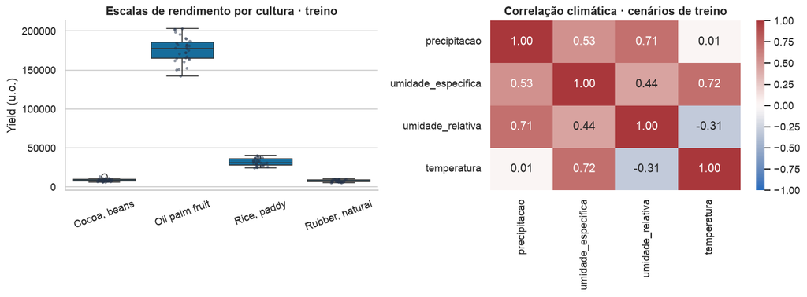

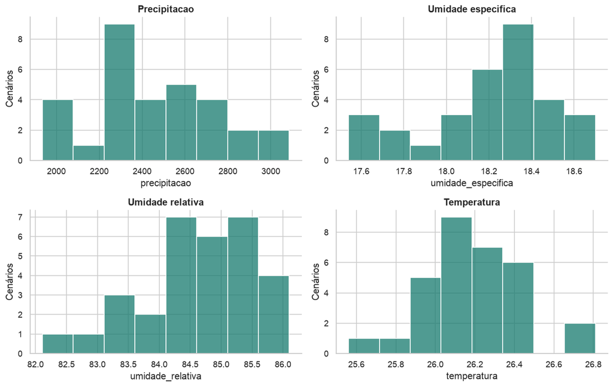

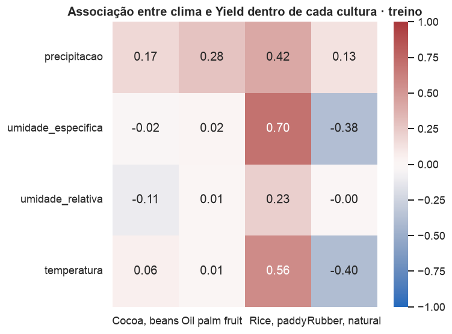

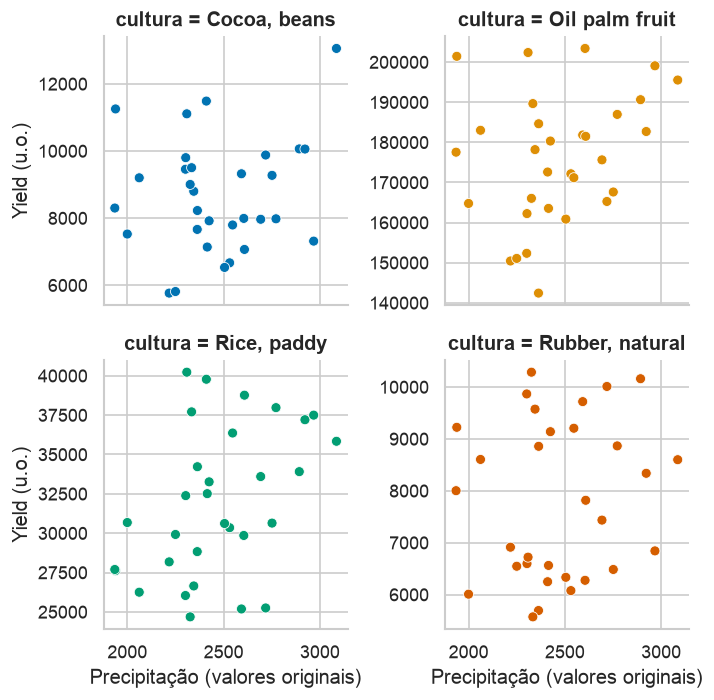

```python
eda = df.iloc[train_idx].copy()
display(eda.groupby('cultura')['rendimento'].describe())
display(eda[clima].drop_duplicates().describe())
fig, axes = plt.subplots(1, 2, figsize=(12, 4.5))
sns.boxplot(data=eda, x='cultura', y='rendimento', ax=axes[0])
sns.stripplot(data=eda, x='cultura', y='rendimento', ax=axes[0], color='#25334a', size=3, alpha=.5)
axes[0].set(title='Escalas de rendimento por cultura · treino', ylabel='Yield (u.o.)', xlabel='')
axes[0].tick_params(axis='x', rotation=20)
sns.heatmap(eda[clima].drop_duplicates().corr(), annot=True, fmt='.2f', cmap='vlag',
            center=0, vmin=-1, vmax=1, ax=axes[1])
axes[1].set_title('Correlação climática · cenários de treino')
figura('exploracao')
fig, axes = plt.subplots(2, 2, figsize=(11, 7))
for coluna, ax in zip(clima, axes.flat):
    sns.histplot(eda[clima].drop_duplicates()[coluna], bins=8, ax=ax, color='#157a6e')
    ax.set(title=coluna.replace('_', ' ').capitalize(), ylabel='Cenários')
figura('distribuicoes_climaticas')
corr_cultura = pd.DataFrame({c: parte[clima + ['rendimento']].corr()['rendimento'].drop('rendimento')
                             for c, parte in eda.groupby('cultura')})
sns.heatmap(corr_cultura, annot=True, fmt='.2f', cmap='vlag', vmin=-1, vmax=1, center=0)
plt.title('Associação entre clima e Yield dentro de cada cultura · treino')
figura('correlacoes_por_cultura')
# Relações visuais por cultura, sem misturar escalas no eixo do rendimento.
g = sns.relplot(data=eda, x='precipitacao', y='rendimento', col='cultura', col_wrap=2,
                hue='cultura', facet_kws={'sharey': False}, height=3, legend=False)
g.set_axis_labels('Precipitação (valores originais)', 'Yield (u.o.)')
figura('precipitacao_rendimento')
```

### Leitura da exploração

Os registros são balanceados por cultura. Dendê (`Oil palm fruit`) ocupa uma escala de rendimento muito superior às demais; cacau e borracha têm escalas próximas. Assim, parte importante de um R² global alto pode vir apenas da identificação da cultura. A base inclui uma faixa estreita de temperatura e umidade, limitando qualquer extrapolação para clima frio ou seco.

Não existem valores ausentes ou duplicatas exatas nesta versão, portanto não é necessário imputar nem remover registros. A repetição do clima entre culturas é uma estrutura da amostra, não uma duplicação de linhas. Os gráficos e a tabela acima permitem observar a direção das associações por cultura sem confundi-las com evidência causal.

## 4. Cinco algoritmos e referências simples

- **Regressão Linear:** referência interpretável e aditiva; não captura interações não lineares por si só.
- **Árvore de Decisão:** regras não lineares; profundidade limitada para reduzir sobreajuste.
- **Random Forest:** média de árvores, diminuindo variância; pode continuar limitada fora do domínio observado.
- **Gradient Boosting:** árvores sequenciais que corrigem erros; usa regularização por profundidade e taxa de aprendizado.
- **SVR com kernel RBF:** relações não lineares; entradas e alvo padronizados, com inversão automática para as unidades originais.

As referências são **média global** e **média por cultura**. A segunda responde se o clima agrega valor além de conhecer a plantação. A média por cultura é implementada por regressão linear sobre one-hot sem intercepto, equivalente à média de treino de cada categoria.

O critério de seleção é **menor RMSE médio na validação**. MAE expressa o erro absoluto típico; RMSE penaliza mais os erros grandes; R² compara com uma previsão constante e pode ser negativo. Todos os erros são calculados na escala original. Os folds não são amostras independentes de uma população ampla; o desvio entre folds é apenas uma medida descritiva de estabilidade.

```python
def pipeline(modelo):
    prep = ColumnTransformer([
        ('clima', StandardScaler(), clima),
        ('cultura', OneHotEncoder(handle_unknown='ignore', sparse_output=False), ['cultura'])
    ])
    return Pipeline([('preparo', prep),
                     ('modelo', TransformedTargetRegressor(regressor=modelo,
                                                          transformer=StandardScaler()))])

candidatos = {
    'Regressão Linear': (LinearRegression(), {}),
    'Árvore de Decisão': (DecisionTreeRegressor(random_state=SEED),
                         {'max_depth': [2, 3, 5], 'min_samples_leaf': [2, 4]}),
    'Random Forest': (RandomForestRegressor(n_estimators=200, random_state=SEED, n_jobs=1),
                      {'max_depth': [3, None], 'min_samples_leaf': [2, 4]}),
    'Gradient Boosting': (GradientBoostingRegressor(random_state=SEED, n_estimators=100),
                          {'max_depth': [1, 2], 'learning_rate': [0.03, 0.1]}),
    'SVR (RBF)': (SVR(kernel='rbf'), {'C': [1, 10, 100], 'epsilon': [0.01, 0.1],
                                    'gamma': ['scale', 0.1]})
}
scoring = {'rmse': 'neg_root_mean_squared_error', 'mae': 'neg_mean_absolute_error', 'r2': 'r2'}
modelos, linhas_cv, buscas = {}, [], {}
for nome, (estimador, grade) in candidatos.items():
    inicio = time.perf_counter()
    busca = GridSearchCV(pipeline(estimador),
                        {f'modelo__regressor__{k}': v for k, v in grade.items()},
                        scoring=scoring, refit='rmse', cv=cv, n_jobs=1, error_score='raise')
    busca.fit(X_train, y_train)
    j = busca.best_index_
    modelos[nome], buscas[nome] = busca.best_estimator_, busca
    linhas_cv.append({'modelo': nome, 'RMSE_CV': -busca.cv_results_['mean_test_rmse'][j],
                     'desvio_RMSE_CV': busca.cv_results_['std_test_rmse'][j],
                     'MAE_CV': -busca.cv_results_['mean_test_mae'][j],
                     'R2_CV': busca.cv_results_['mean_test_r2'][j],
                     'parametros': json.dumps(busca.best_params_, ensure_ascii=False)})
    print(f'{nome}: concluído em {time.perf_counter()-inicio:.1f}s')

baselines = {
    'Média global': DummyRegressor(strategy='mean'),
    'Média por cultura': Pipeline([
        ('cultura', ColumnTransformer([('onehot', OneHotEncoder(handle_unknown='ignore',
                                                               sparse_output=False), ['cultura'])])),
        ('media', LinearRegression(fit_intercept=False))])
}
for nome, base in baselines.items():
    scores = cross_validate(base, X_train, y_train, cv=cv, scoring=scoring, error_score='raise')
    modelos[nome] = clone(base).fit(X_train, y_train)
    linhas_cv.append({'modelo': nome, 'RMSE_CV': -scores['test_rmse'].mean(),
                     'desvio_RMSE_CV': scores['test_rmse'].std(),
                     'MAE_CV': -scores['test_mae'].mean(), 'R2_CV': scores['test_r2'].mean(),
                     'parametros': 'sem busca'})
cv_resultados = pd.DataFrame(linhas_cv).sort_values('RMSE_CV').reset_index(drop=True)
# Escolher e congelar o vencedor entre os cinco algoritmos ANTES de consultar o teste.
vencedor = cv_resultados[cv_resultados.modelo.isin(candidatos)].iloc[0]['modelo']
cv_resultados.to_csv(OUT / 'metricas_validacao.csv', index=False)
display(cv_resultados)
print('Vencedor por validação (congelado):', vencedor)
```

```
Regressão Linear: concluído em 0.0s
Árvore de Decisão: concluído em 0.1s
Random Forest: concluído em 1.3s
Gradient Boosting: concluído em 0.3s
SVR (RBF): concluído em 0.3s
```

|  | modelo | RMSE_CV | desvio_RMSE_CV | MAE_CV | R2_CV | parametros |
| --- | --- | --- | --- | --- | --- | --- |
| 0 | Random Forest | 7,900.048 | 1,832.967 | 4,439.985 | 0.987 | {"modelo__regressor__max_depth": null, "modelo... |
| 1 | Gradient Boosting | 7,971.319 | 1,685.740 | 4,839.290 | 0.987 | {"modelo__regressor__learning_rate": 0.1, "mod... |
| 2 | Regressão Linear | 8,594.692 | 1,209.092 | 5,425.592 | 0.985 | {} |
| 3 | Média por cultura | 8,642.961 | 1,156.889 | 5,180.894 | 0.985 | sem busca |
| 4 | Árvore de Decisão | 8,891.393 | 1,499.057 | 5,158.547 | 0.984 | {"modelo__regressor__max_depth": 3, "modelo__r... |
| 5 | SVR (RBF) | 12,047.246 | 3,912.657 | 7,543.766 | 0.968 | {"modelo__regressor__C": 10, "modelo__regresso... |
| 6 | Média global | 70,370.743 | 2,733.737 | 59,958.734 | -0.001 | sem busca |

```
Vencedor por validação (congelado): Random Forest
```

## 5. Avaliação única no teste reservado

Os cinco algoritmos e as referências são avaliados nas mesmas 32 observações, de oito cenários inteiramente reservados. A ordem do teste não altera o vencedor selecionado. A busca de hiperparâmetros torna a validação otimista em algum grau; o teste independente permite verificar esse efeito, mas oito cenários ainda geram alta incerteza. Não prometo desempenho em outras fazendas, anos ou culturas não observadas.

|  | modelo | MAE | RMSE | R2 |
| --- | --- | --- | --- | --- |
| 2 | Random Forest | 3,597.217 | 5,016.929 | 0.995 |
| 0 | Regressão Linear | 3,985.566 | 5,412.861 | 0.994 |
| 6 | Média por cultura | 4,077.381 | 5,427.703 | 0.994 |
| 3 | Gradient Boosting | 3,938.968 | 5,595.997 | 0.993 |
| 1 | Árvore de Decisão | 3,745.714 | 5,900.258 | 0.993 |
| 4 | SVR (RBF) | 4,365.128 | 6,594.007 | 0.991 |
| 5 | Média global | 59,215.183 | 69,396.447 | -0.000 |

|  | modelo | cultura | n | MAE | RMSE | R2 |
| --- | --- | --- | --- | --- | --- | --- |
| 8 | Random Forest | Cocoa, beans | 8 | 1,615.874 | 1,820.378 | -0.159 |
| 9 | Random Forest | Oil palm fruit | 8 | 8,561.136 | 9,018.880 | 0.027 |
| 10 | Random Forest | Rice, paddy | 8 | 2,760.919 | 3,603.848 | 0.478 |
| 11 | Random Forest | Rubber, natural | 8 | 1,450.939 | 1,742.594 | 0.138 |
| 24 | Média por cultura | Cocoa, beans | 8 | 1,550.254 | 1,972.421 | -0.361 |
| 25 | Média por cultura | Oil palm fruit | 8 | 8,895.355 | 9,209.802 | -0.014 |
| 26 | Média por cultura | Rice, paddy | 8 | 4,025.040 | 5,060.070 | -0.029 |
| 27 | Média por cultura | Rubber, natural | 8 | 1,838.875 | 1,877.394 | -0.000 |

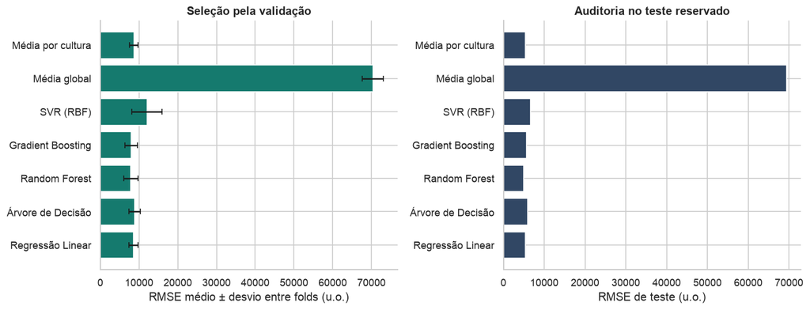

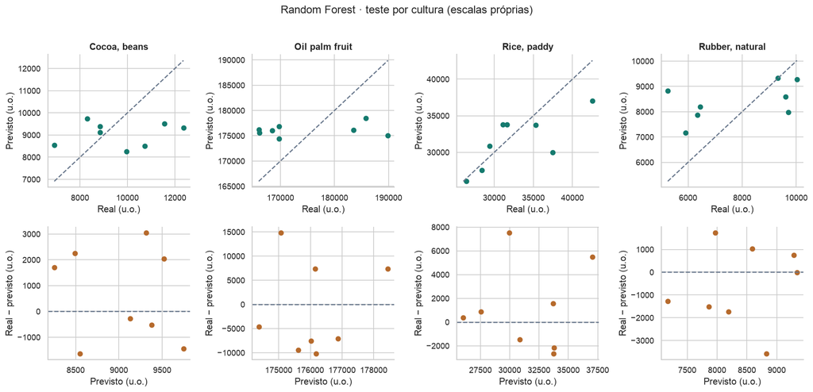

```python
def metricas(real, previsto):
    return {'MAE': mean_absolute_error(real, previsto),
            'RMSE': root_mean_squared_error(real, previsto), 'R2': r2_score(real, previsto)}

predicoes = {nome: estimador.predict(X_test) for nome, estimador in modelos.items()}
teste_resultados = pd.DataFrame([{'modelo': nome, **metricas(y_test, pred)}
                                  for nome, pred in predicoes.items()]).sort_values('RMSE')
por_cultura = []
for nome, pred in predicoes.items():
    for cultura in sorted(X_test.cultura.unique()):
        mask = X_test.cultura.eq(cultura).to_numpy()
        por_cultura.append({'modelo': nome, 'cultura': cultura, 'n': int(mask.sum()),
                           **metricas(y_test.to_numpy()[mask], pred[mask])})
por_cultura = pd.DataFrame(por_cultura)
teste_resultados.to_csv(OUT / 'metricas_teste.csv', index=False)
por_cultura.to_csv(OUT / 'metricas_por_cultura.csv', index=False)
pred_df = df.iloc[test_idx][['cenario', 'cultura', 'rendimento']].copy()
pred_df['previsao'] = predicoes[vencedor]
pred_df['residuo'] = pred_df.rendimento - pred_df.previsao
pred_df.to_csv(OUT / 'predicoes_teste.csv', index_label='linha_csv_zero_based')
display(teste_resultados)
display(por_cultura[por_cultura.modelo.isin([vencedor, 'Média por cultura'])])
fig, axes = plt.subplots(1, 2, figsize=(12, 4.7))
a = cv_resultados.set_index('modelo').loc[list(candidatos) + list(baselines)]
axes[0].barh(a.index, a.RMSE_CV, xerr=a.desvio_RMSE_CV, color='#157a6e', capsize=3)
axes[0].set(title='Seleção pela validação', xlabel='RMSE médio ± desvio entre folds (u.o.)')
b = teste_resultados.set_index('modelo').loc[a.index]
axes[1].barh(b.index, b.RMSE, color='#314764')
axes[1].set(title='Auditoria no teste reservado', xlabel='RMSE de teste (u.o.)')
figura('comparacao_modelos')
fig, axes = plt.subplots(2, 4, figsize=(15, 7))
for j, (cultura, parte) in enumerate(pred_df.groupby('cultura')):
    ax = axes[0, j]
    ax.scatter(parte.rendimento, parte.previsao, color='#157a6e')
    limites = [min(parte.rendimento.min(), parte.previsao.min()),
               max(parte.rendimento.max(), parte.previsao.max())]
    ax.plot(limites, limites, '--', color='#68778c')
    ax.set(title=cultura, xlabel='Real (u.o.)', ylabel='Previsto (u.o.)')
    axes[1, j].scatter(parte.previsao, parte.residuo, color='#b66a2c')
    axes[1, j].axhline(0, linestyle='--', color='#68778c')
    axes[1, j].set(xlabel='Previsto (u.o.)', ylabel='Real − previsto (u.o.)')
fig.suptitle(f'{vencedor} · teste por cultura (escalas próprias)', y=1.02)
figura('diagnostico_teste')
```

## 6. Clusterização: regimes climáticos e produtividade

Esta etapa descritiva usa todos os **39 cenários únicos**, sem repetir cada cenário quatro vezes. As quatro entradas climáticas são padronizadas e agrupadas por K-Means. Testo k de 2 a 6 e seleciono o maior silhouette (empate: menor k). O rendimento **não entra na distância**; é usado somente depois para caracterizar a produtividade dentro de cada cultura e grupo.

Uma PCA de duas dimensões serve apenas para visualizar os grupos calculados nas quatro dimensões. Não é uma regressão nem prova de separação perfeita. A estabilidade é inspecionada com cinco sementes adicionais. Silhouette e estabilidade não validam causalidade ou utilidade agronômica por si sós.

|  | k | silhouette |
| --- | --- | --- |
| 0 | 2 | 0.368 |
| 1 | 3 | 0.399 |
| 2 | 4 | 0.392 |
| 3 | 5 | 0.376 |
| 4 | 6 | 0.369 |

| cluster | n_cenarios | precipitacao | umidade_especifica | umidade_relativa | temperatura |
| --- | --- | --- | --- | --- | --- |
| 1 | 11 | 2,232.217 | 17.805 | 83.916 | 25.986 |
| 2 | 17 | 2,733.518 | 18.338 | 85.652 | 26.119 |
| 3 | 11 | 2,359.025 | 18.393 | 84.145 | 26.481 |

| cultura | cluster | count | mean | median | min | max |
| --- | --- | --- | --- | --- | --- | --- |
| Cocoa, beans | 1 | 11 | 8,847.364 | 9,003.000 | 5765 | 11560 |
|  | 2 | 17 | 8,947.588 | 8,300.000 | 6530 | 13056 |
|  | 3 | 11 | 8,819.273 | 8,226.000 | 7066 | 11487 |
| Oil palm fruit | 1 | 11 | 171,039.909 | 169,783.000 | 150428 | 201436 |
|  | 2 | 17 | 177,074.176 | 175,629.000 | 160862 | 199074 |
|  | 3 | 11 | 178,607.545 | 181,496.000 | 142425 | 203399 |
| Rice, paddy | 1 | 11 | 27,002.727 | 26,648.000 | 24686 | 29918 |
|  | 2 | 17 | 33,147.941 | 33,260.000 | 25251 | 37972 |
|  | 3 | 11 | 35,576.545 | 36,361.000 | 28829 | 42550 |
| Rubber, natural | 1 | 11 | 8,916.000 | 9,322.000 | 6546 | 10285 |
|  | 2 | 17 | 7,776.471 | 7,435.000 | 5249 | 10159 |
|  | 3 | 11 | 6,808.636 | 6,275.000 | 5571 | 9205 |

```
ARI entre sementes (1 = agrupamento equivalente): [1.0, 1.0, 1.0, 1.0, 1.0]
```

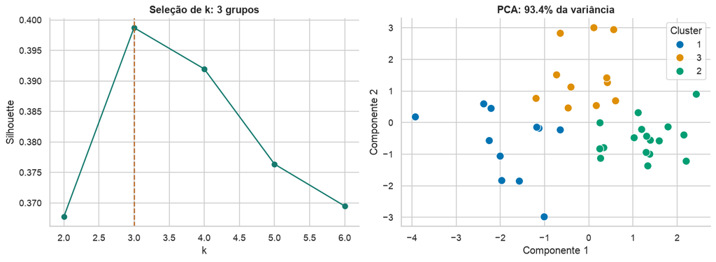

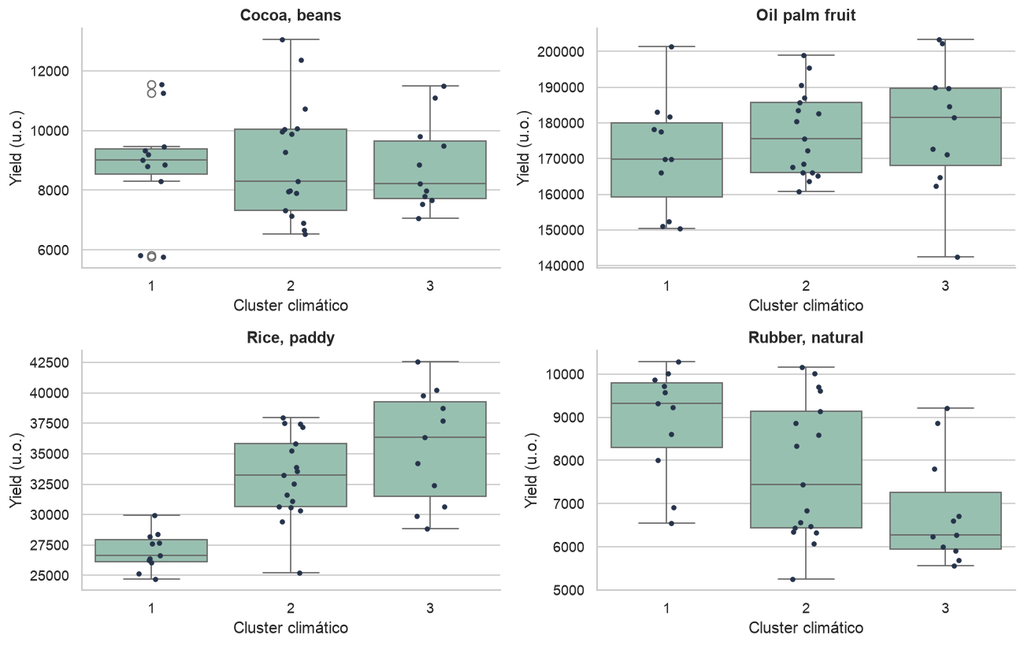

```python
cenarios = df[['cenario'] + clima].drop_duplicates().sort_values('cenario').set_index('cenario')
scaler_cluster = StandardScaler()
Z = scaler_cluster.fit_transform(cenarios)
ks = pd.DataFrame([{'k': k, 'silhouette': silhouette_score(Z, KMeans(n_clusters=k,
                      n_init=30, random_state=SEED).fit_predict(Z))} for k in range(2, 7)])
best_k = int(ks.sort_values(['silhouette', 'k'], ascending=[False, True]).iloc[0]['k'])
kmeans = KMeans(n_clusters=best_k, n_init=30, random_state=SEED).fit(Z)
cenarios['cluster'] = kmeans.labels_ + 1
analise = df.merge(cenarios[['cluster']], left_on='cenario', right_index=True, validate='many_to_one')
perfil = cenarios.groupby('cluster')[clima].mean()
perfil.insert(0, 'n_cenarios', cenarios.groupby('cluster').size())
produtividade = analise.groupby(['cultura', 'cluster']).rendimento.agg(['count', 'mean', 'median', 'min', 'max'])
from sklearn.metrics import adjusted_rand_score
estabilidade = [adjusted_rand_score(kmeans.labels_, KMeans(n_clusters=best_k, n_init=30,
                random_state=s).fit_predict(Z)) for s in [0, 1, 7, 21, 99]]
display(ks)
display(perfil)
display(produtividade)
print('ARI entre sementes (1 = agrupamento equivalente):', estabilidade)
ks.to_csv(OUT / 'selecao_clusters.csv', index=False)
perfil.to_csv(OUT / 'perfil_clusters.csv')
produtividade.to_csv(OUT / 'produtividade_clusters.csv')
analise.to_csv(OUT / 'dados_com_clusters.csv', index=False)
pca = PCA(n_components=2).fit(Z)
proj = pca.transform(Z)
fig, axes = plt.subplots(1, 2, figsize=(12, 4.5))
axes[0].plot(ks.k, ks.silhouette, marker='o', color='#157a6e')
axes[0].axvline(best_k, linestyle='--', color='#b66a2c')
axes[0].set(title=f'Seleção de k: {best_k} grupos', xlabel='k', ylabel='Silhouette')
sns.scatterplot(x=proj[:, 0], y=proj[:, 1], hue=cenarios.cluster.astype(str), s=85, ax=axes[1])
axes[1].set(title=f'PCA: {pca.explained_variance_ratio_.sum():.1%} da variância',
            xlabel='Componente 1', ylabel='Componente 2')
axes[1].legend(title='Cluster')
figura('clusters')
fig, axes = plt.subplots(2, 2, figsize=(11, 7))
for ax, (cultura, parte) in zip(axes.flat, analise.groupby('cultura')):
    sns.boxplot(data=parte, x='cluster', y='rendimento', ax=ax, color='#91c7b1')
    sns.stripplot(data=parte, x='cluster', y='rendimento', ax=ax, color='#25334a', size=4)
    ax.set(title=cultura, ylabel='Yield (u.o.)', xlabel='Cluster climático')
figura('produtividade_clusters')
```

## 7. Cenários discrepantes: outliers de rendimento

Um rendimento de dendê não é comparado diretamente ao de cacau para definir anomalias. Em cada cultura, sinalizo valores abaixo de Q1 − 1,5×IQR ou acima de Q3 + 1,5×IQR. São **candidatos a investigação**, não erros confirmados. A ausência de sinais também é um resultado válido desse critério, sem significar que todos os registros estejam corretos. Nenhuma linha é excluída e nenhum modelo é treinado novamente após consultar estes resultados.

O gráfico desta seção usa os 39 registros de cada cultura. Os quartis podem diferir dos boxplots exploratórios calculados apenas no treino; isso explica eventuais marcações diferentes.

| cultura | Q1 | Q3 | IQR | inferior | superior |
| --- | --- | --- | --- | --- | --- |
| Cocoa, beans | 7,729.000 | 9,918.000 | 2,189.000 | 4,445.500 | 13,201.500 |
| Oil palm fruit | 166,017.500 | 185,230.000 | 19,212.500 | 137,198.750 | 214,048.750 |
| Rice, paddy | 28,293.500 | 36,098.500 | 7,805.000 | 16,586.000 | 47,806.000 |
| Rubber, natural | 6,398.000 | 9,272.500 | 2,874.500 | 2,086.250 | 13,584.250 |

| cultura | sinalizados |
| --- | --- |
| Cocoa, beans | 0 |
| Oil palm fruit | 0 |
| Rice, paddy | 0 |
| Rubber, natural | 0 |

|  | cultura | precipitacao | umidade_especifica | umidade_relativa | temperatura | rendimento | cenario | cluster | inferior | superior | outlier |
| --- | --- | --- | --- | --- | --- | --- | --- | --- | --- | --- | --- |

```
0 registros sinalizados; 0 registros removidos.
```

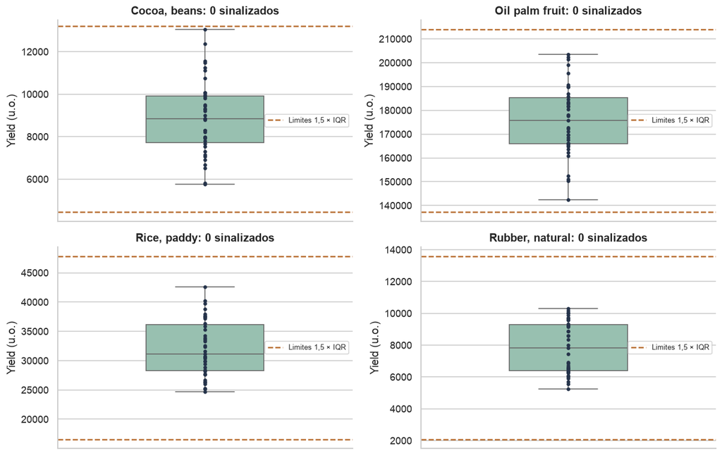

```python
limites_iqr = df.groupby('cultura').rendimento.quantile([.25, .75]).unstack()
limites_iqr.columns = ['Q1', 'Q3']
limites_iqr['IQR'] = limites_iqr.Q3 - limites_iqr.Q1
limites_iqr['inferior'] = limites_iqr.Q1 - 1.5 * limites_iqr.IQR
limites_iqr['superior'] = limites_iqr.Q3 + 1.5 * limites_iqr.IQR
out = analise.join(limites_iqr[['inferior', 'superior']], on='cultura')
out['outlier'] = (out.rendimento < out.inferior) | (out.rendimento > out.superior)
display(limites_iqr)
display(out.groupby('cultura').outlier.sum().rename('sinalizados').to_frame())
display(out.loc[out.outlier])
out.loc[out.outlier].to_csv(OUT / 'outliers.csv', index=False)
print(f'{out.outlier.sum()} registros sinalizados; 0 registros removidos.')
# Visualizar os limites calculados na base completa, separados por cultura.
fig, axes = plt.subplots(2, 2, figsize=(11, 7))
for ax, (cultura, parte) in zip(axes.flat, out.groupby('cultura')):
    sns.boxplot(data=parte, y='rendimento', ax=ax, color='#91c7b1', width=.4)
    sns.stripplot(data=parte, y='rendimento', ax=ax, color='#25334a', size=4, jitter=False)
    ax.axhline(limites_iqr.loc[cultura, 'inferior'], color='#b66a2c', linestyle='--', label='Limites 1,5 × IQR')
    ax.axhline(limites_iqr.loc[cultura, 'superior'], color='#b66a2c', linestyle='--')
    ax.set(title=f'{cultura}: {int(parte.outlier.sum())} sinalizados', ylabel='Yield (u.o.)', xlabel='')
    ax.legend(fontsize=8)
figura('outliers_por_cultura')
```

## 8. Exemplo de previsão e uso responsável

A entrada é um DataFrame com a cultura conhecida e as quatro condições na **mesma escala do CSV**. A saída é um vetor de rendimentos nas unidades originais. O exemplo usa uma condição do teste já avaliado, não cria uma nova evidência de generalização. Culturas desconhecidas, números não finitos e extrapolações além do intervalo observado no treino são recusados neste demonstrador. O modelo permanece ajustado apenas ao treino para preservar a rastreabilidade da avaliação.

```python
def prever(entrada):
    if not isinstance(entrada, pd.DataFrame) or entrada.empty:
        raise ValueError('Forneça um DataFrame não vazio.')
    if set(entrada.columns) != set(features):
        raise ValueError(f'Colunas necessárias: {features}')
    if not entrada.cultura.isin(X_train.cultura.unique()).all():
        raise ValueError('Cultura desconhecida: use uma das quatro culturas da base.')
    try:
        numeros = entrada[clima].astype(float)
    except (TypeError, ValueError) as erro:
        raise ValueError('As condições climáticas devem ser numéricas.') from erro
    if not np.isfinite(numeros.to_numpy()).all():
        raise ValueError('Condições ausentes ou não finitas.')
    if ((numeros < X_train[clima].min()) | (numeros > X_train[clima].max())).any().any():
        raise ValueError('Entrada fora dos limites de treino; extrapolação não autorizada.')
    valida = entrada.copy()
    valida[clima] = numeros
    return modelos[vencedor].predict(valida[features])

# Encontrar um exemplo de teste dentro dos limites de entrada observados no treino.
dentro = ((X_test[clima] >= X_train[clima].min()) &
          (X_test[clima] <= X_train[clima].max())).all(axis=1)
exemplo = X_test.loc[dentro].iloc[[0]].copy()
display(exemplo)
print('Previsão (u.o.):', prever(exemplo).round(2))
print('Valor observado (u.o.):', y_test.loc[exemplo.index].to_numpy())
# Guardas significativas da interface de demonstração.
for invalida in [exemplo.assign(cultura='cultura desconhecida'),
                 exemplo.assign(temperatura=np.nan), exemplo.assign(temperatura=1000),
                 exemplo.iloc[:0]]:
    try:
        prever(invalida)
    except ValueError:
        pass
    else:
        raise AssertionError('Uma entrada inválida foi aceita.')

resumo = {'autor': 'Eduardo Rick', 'rm': '573745', 'sha256_csv': sha,
          'n_registros': len(df), 'n_cenarios': df.cenario.nunique(),
          'n_treino': len(train_idx), 'n_teste': len(test_idx), 'vencedor_cv': vencedor,
          'teste_vencedor': metricas(y_test, predicoes[vencedor]),
          'teste_media_cultura': metricas(y_test, predicoes['Média por cultura']),
          'k': best_k, 'silhouette': float(ks.loc[ks.k.eq(best_k), 'silhouette'].iloc[0]),
          'outliers': int(out.outlier.sum()), 'ari_sementes': estabilidade}
(OUT / 'resumo.json').write_text(json.dumps(resumo, ensure_ascii=False, indent=2), encoding='utf-8')
print('Verificações de dados, separação por grupos e entradas inválidas: OK.')
```

|  | cultura | precipitacao | umidade_especifica | umidade_relativa | temperatura |
| --- | --- | --- | --- | --- | --- |
| 0 | Cocoa, beans | 2,248.920 | 17.720 | 83.400 | 26.010 |

```
Previsão (u.o.): [9518.33]
Valor observado (u.o.): [11560]
Verificações de dados, separação por grupos e entradas inválidas: OK.
```

## 9. Conclusões, pontos fortes e limitações

**Resultados executados:** Random Forest foi selecionado pela validação. No teste, obteve MAE **3,597.22**, RMSE **5,016.93** (u.o.) e R² **0.9948**. A referência pela média de cada cultura obteve RMSE **5,427.70** e R² **0.9939**. A diferença de RMSE contra essa referência é **7.57%** (valores negativos significam piora). O resultado evidencia por que a média por cultura é um controle mais exigente que a média global.

**Desempenho dentro de cada cultura:**

| cultura | n | MAE | RMSE | R2 |
| --- | --- | --- | --- | --- |
| Cocoa, beans | 8 | 1615.874 | 1820.378 | -0.159 |
| Oil palm fruit | 8 | 8561.136 | 9018.880 | 0.027 |
| Rice, paddy | 8 | 2760.919 | 3603.848 | 0.478 |
| Rubber, natural | 8 | 1450.939 | 1742.594 | 0.138 |

R² negativo significa desempenho inferior à média observada daquele subconjunto de teste; não deve ser ocultado pelo R² agregado. A comparação operacional com uma média disponível no treino é fornecida pela referência por cultura na seção 5.

**Grupos:** foram selecionados **3 clusters**, silhouette **0.399**. A estabilidade entre sementes apresentou ARI mínimo **1.000**. Os perfis abaixo caracterizam os agrupamentos nas unidades originais:

| cluster | n_cenarios | precipitacao | umidade_especifica | umidade_relativa | temperatura |
| --- | --- | --- | --- | --- | --- |
| 1.00 | 11.00 | 2232.22 | 17.81 | 83.92 | 25.99 |
| 2.00 | 17.00 | 2733.52 | 18.34 | 85.65 | 26.12 |
| 3.00 | 11.00 | 2359.02 | 18.39 | 84.15 | 26.48 |

**Associações de produtividade:**

- Cocoa, beans: maior média no cluster 2 (8,947.59 u.o.); menor no cluster 3 (8,819.27 u.o.).
- Oil palm fruit: maior média no cluster 3 (178,607.55 u.o.); menor no cluster 1 (171,039.91 u.o.).
- Rice, paddy: maior média no cluster 3 (35,576.55 u.o.); menor no cluster 1 (27,002.73 u.o.).
- Rubber, natural: maior média no cluster 1 (8,916.00 u.o.); menor no cluster 3 (6,808.64 u.o.).

Essas diferenças descrevem a amostra e não estimam o efeito de mudar o clima. O tamanho de cada grupo e a sobreposição nos boxplots devem acompanhar a leitura das médias.

**Outliers:** 0 registro(s) sinalizado(s) pelo IQR por cultura; nenhum removido. Isso indica apenas ausência de sinais pelo critério adotado, sem garantir ausência de anomalias.

**Pontos fortes:** dados originais preservados; auditoria executável; comparação de cinco famílias de modelos; referências global e por cultura; separação por cenário; pré-processamento dentro dos folds; análise de erros por cultura; clusters sem usar o alvo e tratamento transparente de outliers.

**Limitações:** apenas 39 cenários climáticos e oito no teste; unidades não confirmadas; ausência de datas, localização e variáveis do solo; restrição a quatro culturas; faixa climática estreita. Mesmo quando o R² agregado é alto, isso não significa alta precisão em cada cultura. Escolher o menor RMSE de validação em escala original também atribui maior influência à cultura de maior escala; a análise por cultura é essencial para interpretar essa escolha.

Os clusters descrevem **associações de produtividade**, não uma evolução ao longo do tempo ou uma receita de irrigação. A validação em novas safras exigiria dados datados e independentes, verificação das unidades e avaliação agronômica. Antes de uso real, também seriam necessários intervalos de previsão calibrados, monitoramento de mudança dos dados e teste de memória/latência na máquina de nuvem escolhida. Não há implantação em produção nesta atividade.

### Referências metodológicas

- [scikit-learn: validação cruzada e divisões por grupos](https://scikit-learn.org/stable/modules/cross_validation.html)
- [scikit-learn: prevenção de vazamento e pipelines](https://scikit-learn.org/stable/common_pitfalls.html)
- [scikit-learn: métricas de regressão](https://scikit-learn.org/stable/modules/model_evaluation.html#regression-metrics)
- [scikit-learn: K-Means](https://scikit-learn.org/stable/modules/clustering.html#k-means)
- Fonte dos dados e requisitos: arquivo e enunciado disponibilizados no portal FIAP, Fase 5.